# Behavioral Risk Factor Surveillance System Analysis

Myles Lane

3/23/2020

## Import and Install

```r
#Set Directory, Import files and libraries
setwd("/Users/myles/Desktop/Home/INST408/ICE/ICE_7")

BRFSS<- read.csv("BRFSS.csv")

library(ggplot2)
library(summarytools)
library(dplyr)
```

## EDA

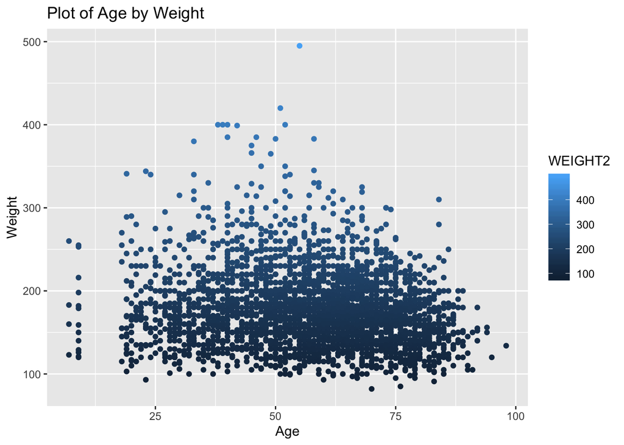

```r
#Filter to only include rows with weight recorded
BRFSS_weight <- filter(BRFSS,WEIGHT2 < 1000)

#Create Scatterplot of Age by Weight
ggplot(data = BRFSS_weight) +
  geom_point(mapping = aes(x=AGE, y=WEIGHT2, color=WEIGHT2)) +
  labs(title="Plot of Age by Weight",x="Age",y="Weight") +
  scale_color_gradient()
```

It appears there is no correlation between age and weight in this scatterplot.

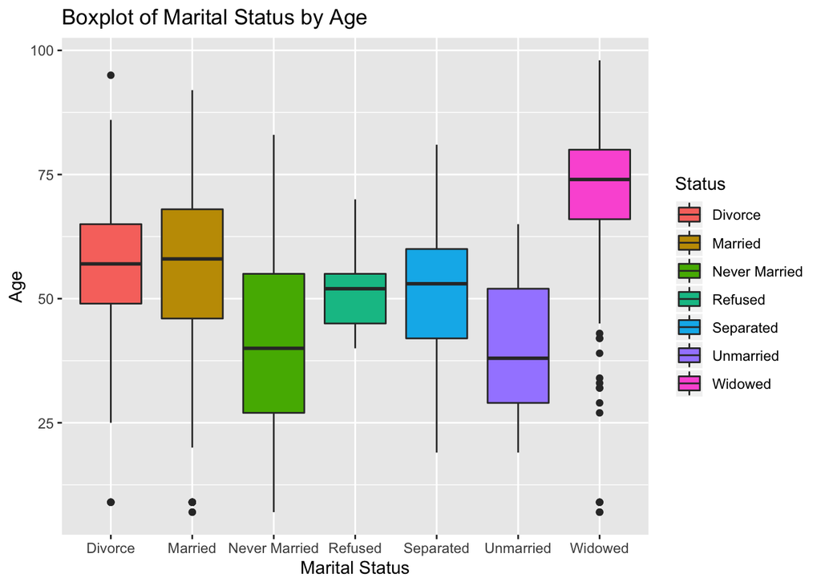

```r
#Recode marital status
BRFSS_marital <- mutate(BRFSS, MARITAL = ifelse(MARITAL == 1, "Married",
                                         ifelse(MARITAL == 2, "Divorce",
                                         ifelse(MARITAL == 3, "Widowed",
                                         ifelse(MARITAL == 4, "Separated",
                                         ifelse(MARITAL == 5, "Never Married",
                                         ifelse(MARITAL == 6, "Unmarried", "Refused")))))))

#Create boxplot of marital by age
ggplot(data = BRFSS_marital) +
  geom_boxplot(mapping = aes(x=MARITAL, y=AGE, fill=MARITAL)) +
  labs(title="Boxplot of Marital Status by Age",x="Marital Status",y="Age", fill="Status")
```

This boxplot shows a median age of around 58 for those that are divorced or married. The median age is slightly lower for respondents that are separated or refused to answer at 53. The lowest median ages at 38 are those that have never married or are unmarried. Finally, the highest median age at age 74 is those that are widowed, however this group has several outliers that are much younger.

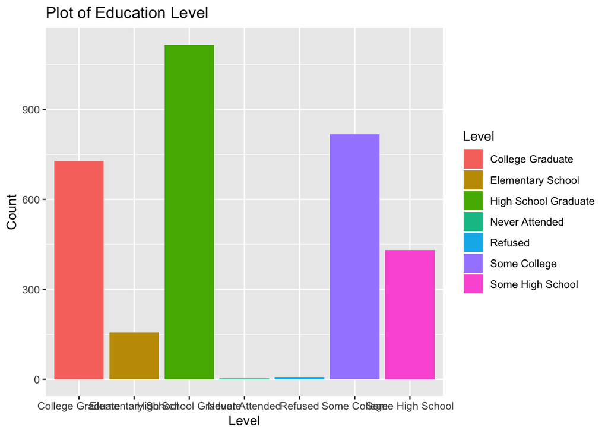

```r
#Recode education
BRFSS_educa <- mutate(BRFSS, EDUCA = ifelse(EDUCA==1, "Never Attended",
                                     ifelse(EDUCA==2, "Elementary School",
                                     ifelse(EDUCA==3, "Some High School",
                                     ifelse(EDUCA==4, "High School Graduate",
                                     ifelse(EDUCA==5, "Some College",
                                     ifelse(EDUCA==6, "College Graduate",
                                     ifelse(EDUCA==9, "Refused", "Missing"))))))))
#Bar chart of education
ggplot(data = BRFSS_educa) +
  geom_bar(mapping = aes(x=EDUCA, fill=EDUCA))+
  labs(title="Plot of Education Level",x="Level",y="Count", fill="Level")
```

```r
#Frequency table of education
freq(BRFSS_educa$EDUCA)
```

```
## Frequencies
## BRFSS_educa$EDUCA
## Type: Character
##
##                              Freq   % Valid   % Valid Cum.   % Total   % Total Cum.
## -------------------------- ------ --------- -------------- --------- --------------
##           College Graduate    729     22.36          22.36     22.36          22.36
##          Elementary School    156      4.79          27.15      4.79          27.15
##       High School Graduate   1116     34.23          61.38     34.23          61.38
##             Never Attended      3      0.09          61.47      0.09          61.47
##                    Refused      8      0.25          61.72      0.25          61.72
##               Some College    817     25.06          86.78     25.06          86.78
##           Some High School    431     13.22         100.00     13.22         100.00
##                       <NA>      0                               0.00         100.00
##                      Total   3260    100.00         100.00    100.00         100.00
```

This table shows a more detailed look at what the graph above shows. Most of the data is made up of people who at least graduated high school. Only 18% have less than a high school education.

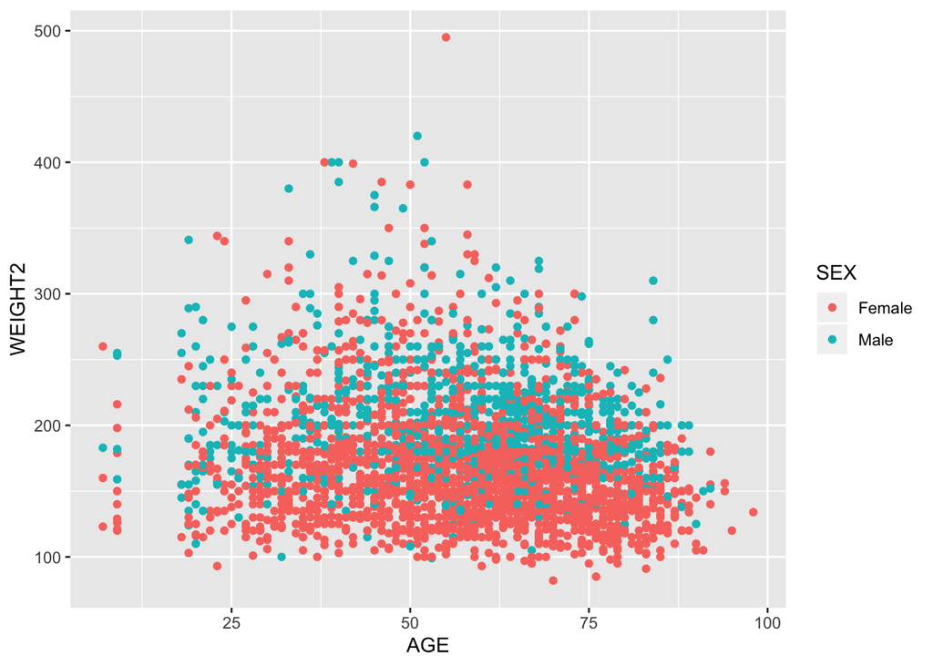

```r
#Recode Sex variable
BRFSS_weight<- mutate(BRFSS_weight, SEX = ifelse(SEX==1, "Male",
                                          ifelse(SEX==2, "Female", SEX)))

ggplot(data=BRFSS_weight) +
  geom_point(mapping = aes(x=AGE,y=WEIGHT2, color=SEX))
```

This scatterplot is the same as the previous scatterplot except grouped by the sex variable. Again there is no correlation between the variables, however the male weights seem to be higher than females, which could be expected.

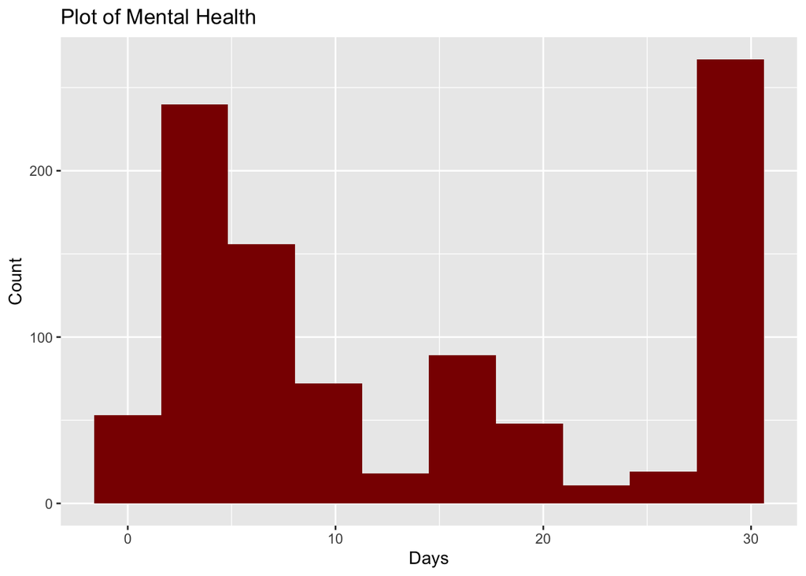

```r
#Filter out those that said none or were missing in mental health variable
BRFSS_mental <- filter(BRFSS, MENTHLTH < 31)

#Histogram of mental health
ggplot(data = BRFSS_mental) +
  geom_histogram(mapping = aes(x=MENTHLTH), bins = 10, fill="Dark red")+
  labs(title="Plot of Mental Health",x="Days",y="Count")
```

The histogram shows spikes in the number of days with bad mental health at 5 days and 30 days. These peak at around 240 and 260 cases, respectively.